# lab2

Addison Schmidt

9/18/2021

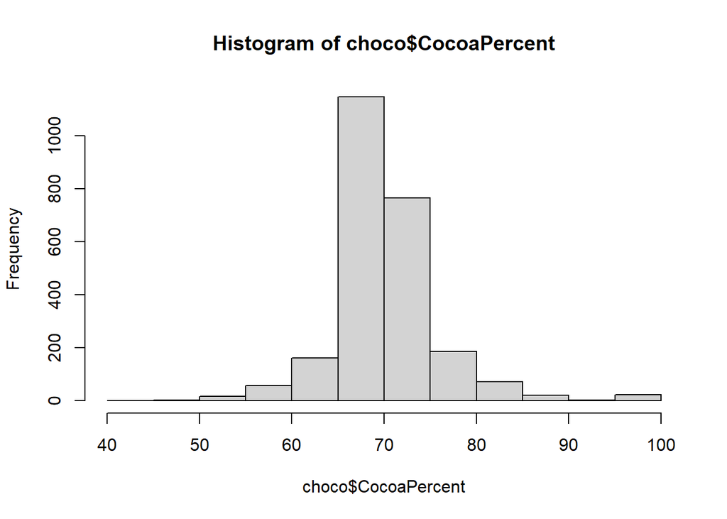

```r
library(classdata)
hist(choco$CocoaPercent)
```

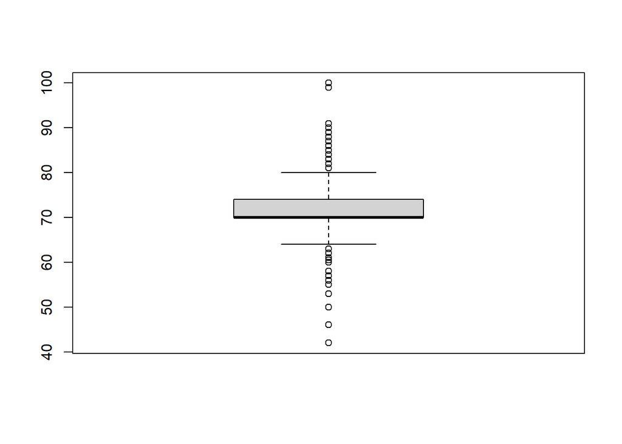

```r
boxplot(choco$CocoaPercent)
```

```r
summary(choco$CocoaPercent)
```

```
##    Min. 1st Qu.  Median    Mean 3rd Qu.    Max.
##   42.00   70.00   70.00   71.65   74.00  100.00
```

2. Burma is tied for the fewest with just 1 rating, while Venezuala has the most with over 200. Unsurprisingly, countries with more cocoa exports seem to tend towards having more ratings. The first graph shows the 30 countries with the fewest, and the second the 31 with the most in the dataset.

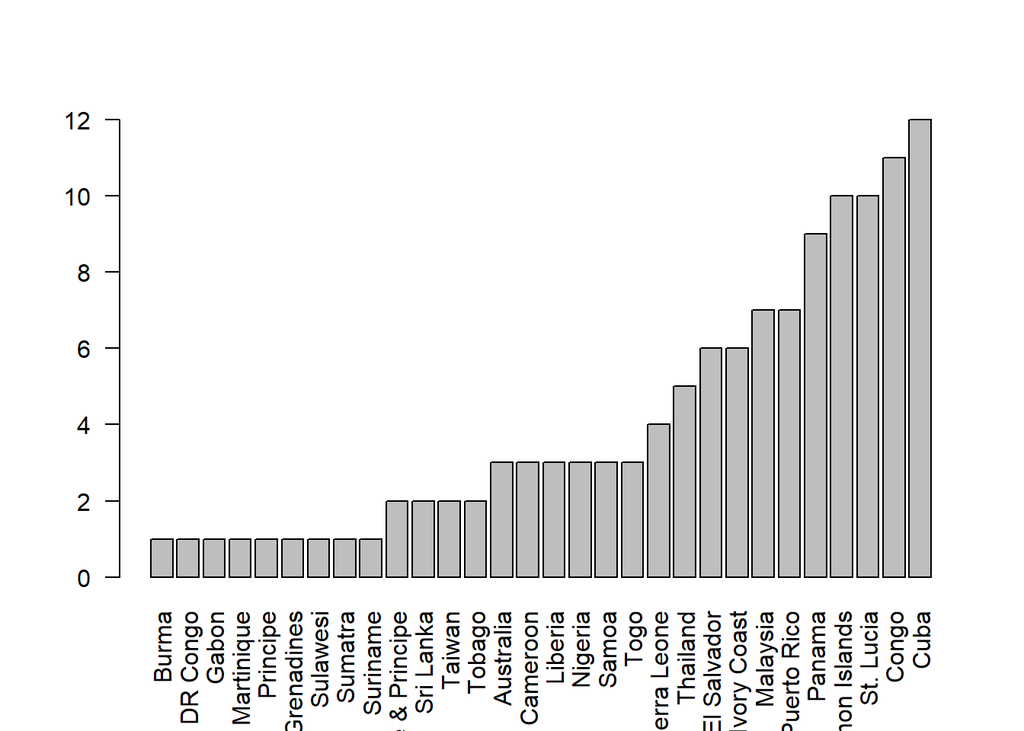

```r
x = table(choco$CountryBeanOrigin)
x = sort(x)
barplot(x[1:30], las=2)
```

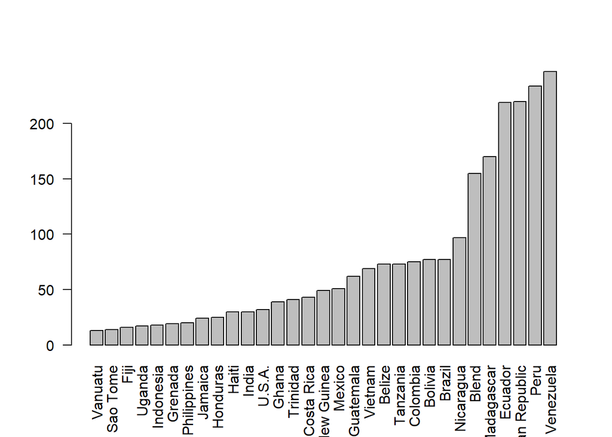

```r
barplot(x[31:61], las=2)
```

3. The data show that there is a negative correlation between the cocoa percent and its rating. We are 95% certain that the correlation is between -0.18656 and -0.10912. This is shown by the linear regression line on the scatterplot. The points themselves are difficult to read because they are numberous. When excluding chocolates with more than 95% cocoa, we still find that this correlation holds - although to a lesser degree - yielding a 95% confidence interval from -0.10497 to -0.02577.

```r
cor.test(choco$CocoaPercent, choco$Rating)
```

```
##
##  Pearson's product-moment correlation
##
## data:  choco$CocoaPercent and choco$Rating
## t = -7.4106, df = 2450, p-value = 1.722e-13
## alternative hypothesis: true correlation is not equal to 0
## 95 percent confidence interval:
##  -0.1865573 -0.1091211
## sample estimates:
##        cor
## -0.1480661
```

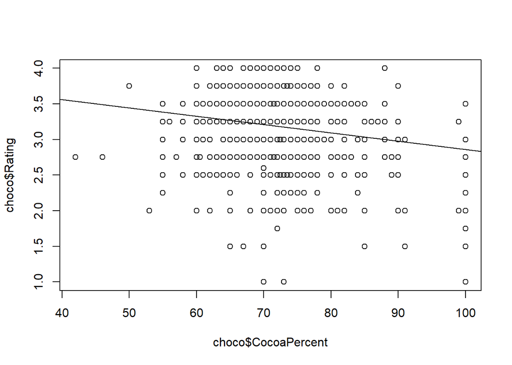

```r
plot(choco$CocoaPercent, choco$Rating)
model = lm(choco$Rating ~ choco$CocoaPercent, data=choco)
abline(model)
```

```r
smaller = choco[choco$CocoaPercent < 95,]
cor.test(smaller$CocoaPercent, smaller$Rating)
```

```
##
##  Pearson's product-moment correlation
##
## data:  smaller$CocoaPercent and smaller$Rating
## t = -3.2326, df = 2427, p-value = 0.001243
## alternative hypothesis: true correlation is not equal to 0
## 95 percent confidence interval:
##  -0.10497378 -0.02577096
## sample estimates:
##         cor
## -0.06547549
```

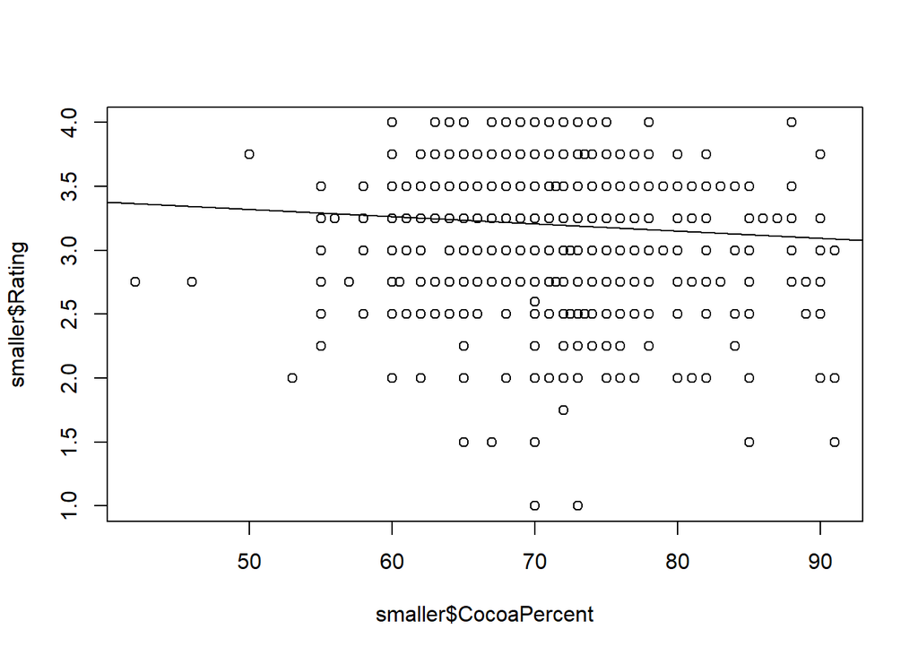

```r
plot(smaller$CocoaPercent, smaller$Rating)
model = lm(smaller$Rating ~ smaller$CocoaPercent, data=smaller)
abline(model)
```

4. Although there is variance in the mean, medians, modes, etc. of flavor ratings across countries as seen in the first graph, we do not see a significant difference in ratings amongst countries with at least 100 ratings. The variace amongst other countries is likely driven by random variance, and is not statistically significant. Therefore, this dataset does not show us a significant difference between countries.

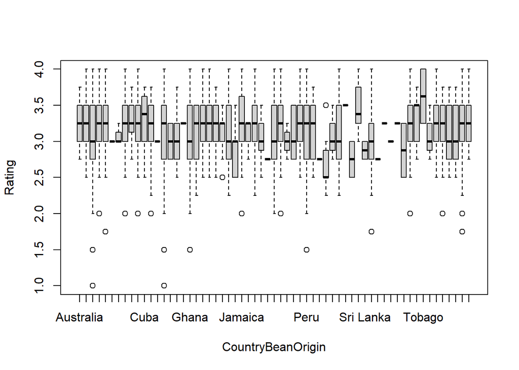

```r
boxplot(Rating ~ CountryBeanOrigin ,data=choco)
```

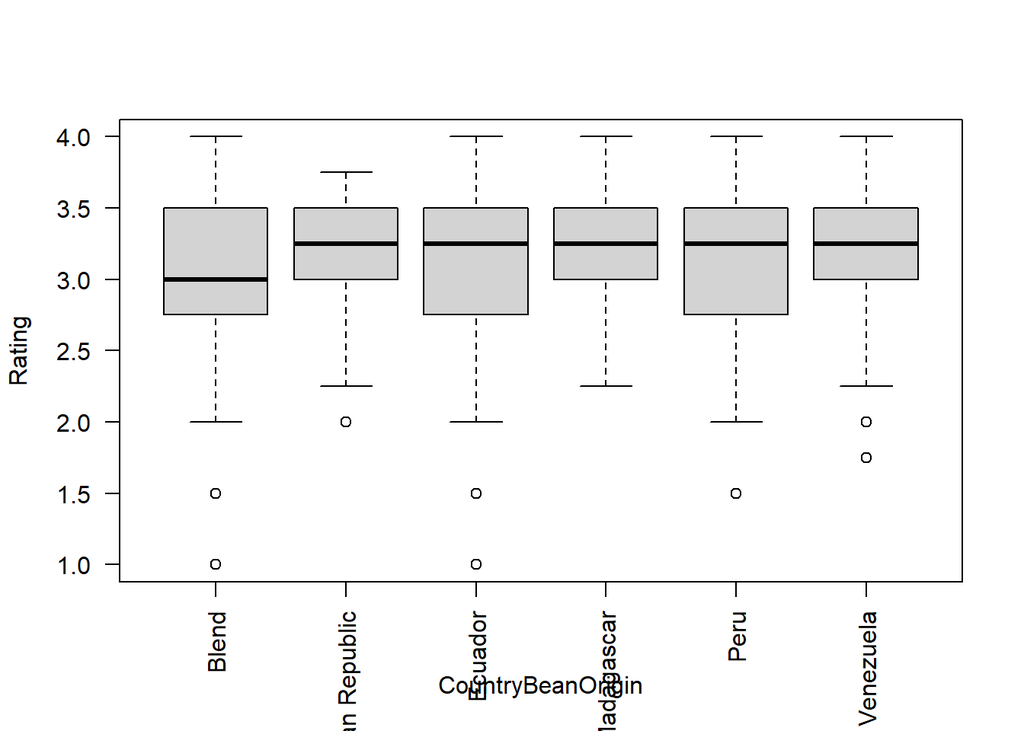

```r
most = choco[(x[choco$CountryBeanOrigin] > 100),]
boxplot(Rating ~ CountryBeanOrigin, data=most, las=2)
```

```r
labels = c("Blend", "Dominican Republic", "Ecuador", "Madagascar", "Peru", "Venezuela")
for(label in labels) {
  temp = most[most$CountryBeanOrigin == label,]
  print(label)
  print(summary(temp$Rating))
}
```

```
## [1] "Blend"
##    Min. 1st Qu.  Median    Mean 3rd Qu.    Max.    NA's
##   1.000   2.750   3.000   3.037   3.500   4.000       1
## [1] "Dominican Republic"
##    Min. 1st Qu.  Median    Mean 3rd Qu.    Max.    NA's
##   2.000   3.000   3.250   3.214   3.500   3.750       1
## [1] "Ecuador"
##    Min. 1st Qu.  Median    Mean 3rd Qu.    Max.    NA's
##   1.000   2.750   3.250   3.164   3.500   4.000       1
## [1] "Madagascar"
##    Min. 1st Qu.  Median    Mean 3rd Qu.    Max.    NA's
##   2.250   3.000   3.250   3.265   3.500   4.000       1
## [1] "Peru"
##    Min. 1st Qu.  Median    Mean 3rd Qu.    Max.    NA's
##   1.500   2.750   3.250   3.191   3.500   4.000       1
## [1] "Venezuela"
##    Min. 1st Qu.  Median    Mean 3rd Qu.    Max.    NA's
##   1.750   3.000   3.250   3.226   3.500   4.000       1
```

5. I will first compare the company to CocoaPercent amongst the companies with the most reviews. The interesting part of this analysis is the variance within a company, as well as the differences between the cocoa amounts they use.

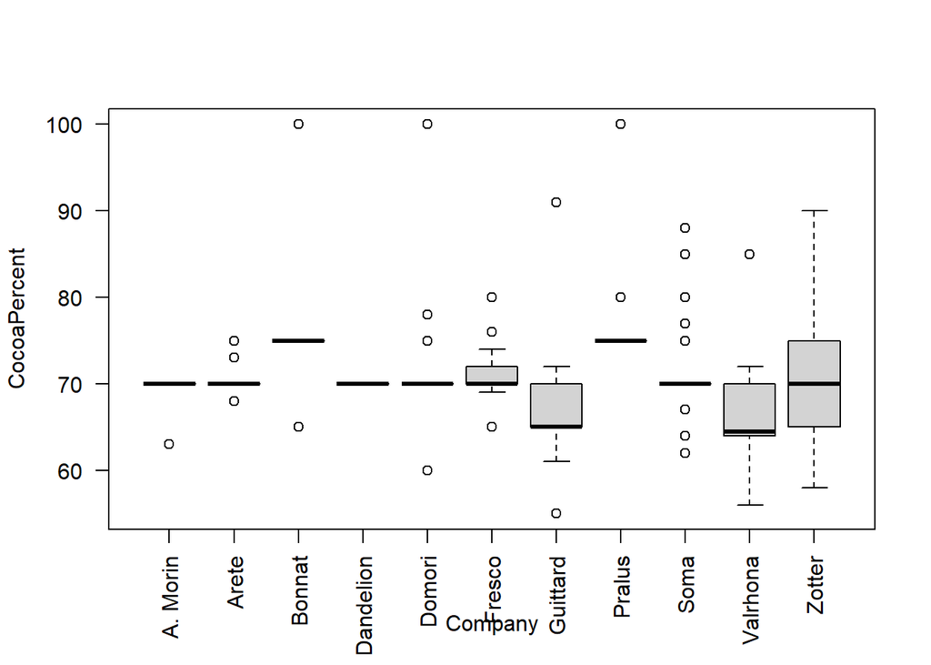

```r
tableCompany = table(choco$Company)
tableCompany = sort(tableCompany)
mostCompany = choco[(tableCompany[choco$Company] > 20),]
boxplot(CocoaPercent ~ Company, data=mostCompany, las=2)
```

```r
labelsCompany = c("A. Morin", "Arete", "Bonnat", "Dandelion", "Domori", "Fresco", "Guitard", "Pralus", "Soma", "Valrhona", "Zotter")
for(label in labelsCompany) {
  tempCompany = mostCompany[mostCompany$Company == label,]
  print(label)
  print(summary(tempCompany$CocoaPercent))
}
```

```
## [1] "A. Morin"
##    Min. 1st Qu.  Median    Mean 3rd Qu.    Max.
##   63.00   70.00   70.00   68.88   70.00   70.00
## [1] "Arete"
##    Min. 1st Qu.  Median    Mean 3rd Qu.    Max.
##   68.00   70.00   70.00   70.53   70.00   75.00
## [1] "Bonnat"
##    Min. 1st Qu.  Median    Mean 3rd Qu.    Max.
##    65.0    75.0    75.0    75.5    75.0   100.0
## [1] "Dandelion"
##    Min. 1st Qu.  Median    Mean 3rd Qu.    Max.
##      70      70      70      70      70      70
## [1] "Domori"
##    Min. 1st Qu.  Median    Mean 3rd Qu.    Max.
##   60.00   70.00   70.00   71.43   70.00  100.00
## [1] "Fresco"
##    Min. 1st Qu.  Median    Mean 3rd Qu.    Max.
##   65.00   70.00   70.00   71.13   72.00   80.00
## [1] "Guitard"
##    Min. 1st Qu.  Median    Mean 3rd Qu.    Max.
##
## [1] "Pralus"
##    Min. 1st Qu.  Median    Mean 3rd Qu.    Max.
##    75.0    75.0    75.0    76.2    75.0   100.0
## [1] "Soma"
##    Min. 1st Qu.  Median    Mean 3rd Qu.    Max.
##   62.00   70.00   70.00   70.83   70.00   88.00
## [1] "Valrhona"
##    Min. 1st Qu.  Median    Mean 3rd Qu.    Max.
##   56.00   64.00   64.50   67.18   69.75   85.00
## [1] "Zotter"
##    Min. 1st Qu.  Median    Mean 3rd Qu.    Max.
##   58.00   65.00   70.00   70.19   75.00   90.00
```

Secondly, I will compare the review date by rating to see how the ratings have trended over time. The year 2021 will be omitted because reviews may vary by season, and not all seasons of 2021 have passed yet.

```r
choco = choco[choco$ReviewDate < 2021, ]
cor.test(choco$ReviewDate, choco$Rating)
```

```
##
##  Pearson's product-moment correlation
##
## data:  choco$ReviewDate and choco$Rating
## t = 4.5901, df = 2353, p-value = 4.663e-06
## alternative hypothesis: true correlation is not equal to 0
## 95 percent confidence interval:
##  0.05401918 0.13408699
## sample estimates:
##        cor
## 0.09420542
```

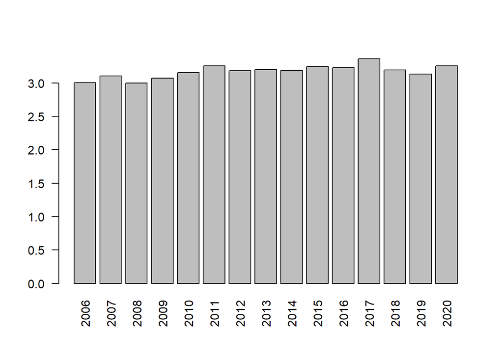

```r
x = c()
labels = c()
for(i in 2006:2020) {
  tmp = choco[choco$ReviewDate == i,]
  x[i-2005] = mean(tmp$Rating)
  labels[i-2005] = i
}
barplot(x, names.arg=labels, las=2)
```

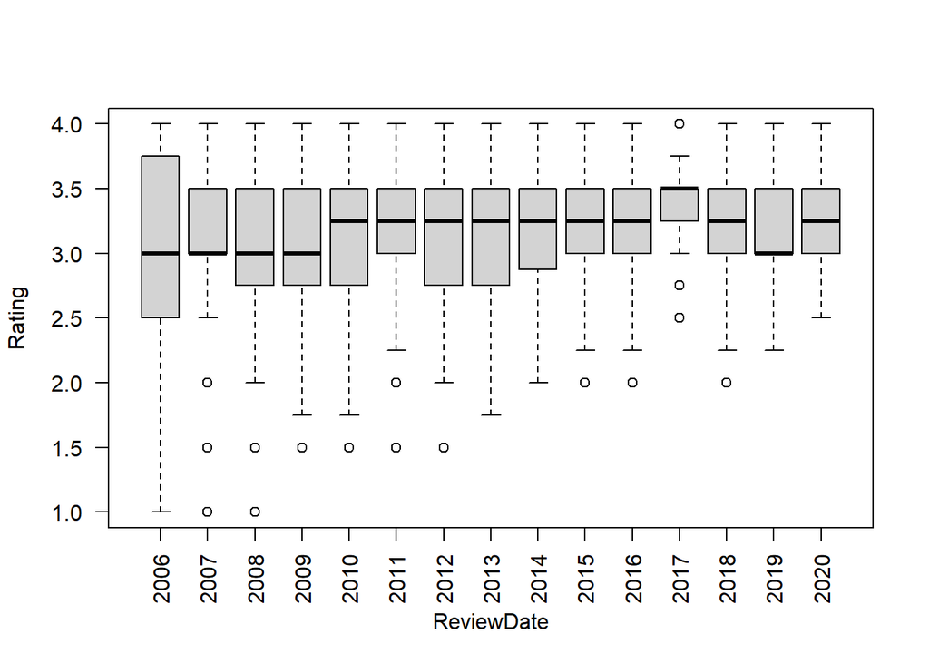

```r
boxplot(Rating ~ ReviewDate, data=choco, las=2)
```

While it’s hard to see the trend in either the barplot or boxplot, we can construct a 95% confidence interval that the correlation is between 0.054 and 0.134. This is a small positive correlation. From the boxplot, we can see that the interquartile range was greatest in 2006, and was lowest in 2017.